# 多変量解析法入門第2章

Ryotaro Nozawa

2021/12/26

## 問題2.2

問題文：正規分布$N(\mu, \sigma^2)$からn=10個のデータをランダムに取った。  
3, 4, 2, 9, 6, 7, 5, 6, 5, 4  
(1) $H_0:\mu=3.0, H_1:\mu≠3.0$を有意水準5%で検定せよ。また、母平均$\mu$の信頼率95%の信頼区間を求めよ。  
(2) $H_0:\sigma^2=2.0^2, H_1:\sigma^2≠2.0^2$を有意水準5%で検定せよ。また、母分散$\sigma^2$の信頼率95%の信頼区間を求めよ。

回答：  
(1)

### 検定

```r
# データ準備
x = c(3, 4, 2, 9, 6, 7, 5, 6, 5, 4)
```

$H_0:\mu=3.0$が成り立つとき、検定統計量$t_0=\frac{(\bar{x}-\mu)}{s'/\sqrt{N}}$ (s’は不偏標準偏差)は、自由度N-1のt分布に従う。

```r
# t0の計算
(t0 = (mean(x)-3)/(stats::sd(x)/sqrt(length(x))))
```

```
## [1] 3.279649
```

有意水準5%で両側検定する。まず、棄却域の境界のt値を算出する。

```r
# 上側確率2.5%に対応するt値(境界線)
stats::qt(0.025, df=length(x)-1, lower.tail=FALSE)
```

```
## [1] 2.262157
```

```r
# 下側確率2.5%に対応するt値(境界線)
stats::qt(0.025, df=length(x)-1)
```

```
## [1] -2.262157
```

t分布と検定統計量t0(青線)と棄却域の境界線(赤線)を描画する。

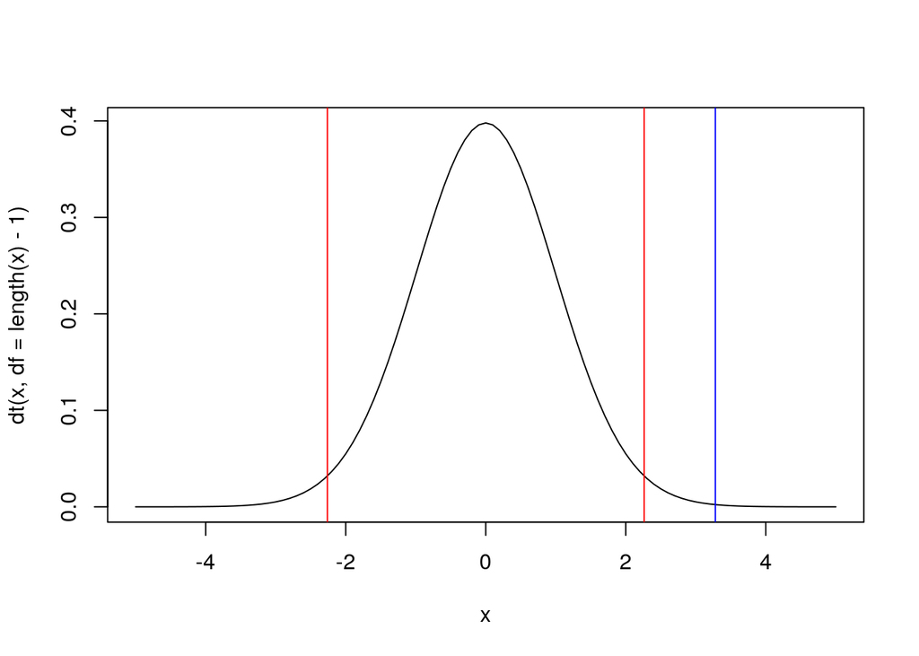

```r
graphics::par(new=TRUE)
graphics::curve(dt(x, df=length(x)-1), from=-5, to=5)
graphics::abline(v=t0, col="blue")
graphics::abline(v=stats::qt(0.025, df=length(x)-1, lower.tail=FALSE), col="red")
graphics::abline(v=stats::qt(0.025, df=length(x)-1), col="red")
```

$|t_0|>t_{\alpha/2}(N-1)$より、帰無仮説$H_0:\mu=3.0$は棄却される。

### 信頼区間の算出

次に、母平均$\mu$の信頼率95%の信頼区間を算出する。

$-t_{\alpha/2}(N-1)<\frac{(\bar{x}-\mu)}{s'/\sqrt{N}}<t_{\alpha/2}(N-1)$より、  
$\bar{x}-t_{\alpha/2}(N-1)*\frac{s'}{\sqrt{N}}<\mu<\bar{x}+t_{\alpha/2}(N-1)*\frac{s'}{\sqrt{N}}$

```r
# 母数の95％信頼区間の算出
(mu_lower = mean(x) - stats::qt(0.025, df=length(x)-1, lower.tail=FALSE) * stats::sd(x)/sqrt(length(x)))
```

```
## [1] 3.651513
```

```r
(mu_upper = mean(x) + stats::qt(0.025, df=length(x)-1, lower.tail=FALSE) * stats::sd(x)/sqrt(length(x)))
```

```
## [1] 6.548487
```

よって、母平均$\mu$の信頼率95%の信頼区間は(95% CI: [3.65, 6.55])